# DRAFT: BC Chronic Diseases trends: A joinpoint regression analysis

Mahmoodur Rahman

13 June, 2022

# Calling the libraries:

```r
library(readr)
library(tidyr)
library(dplyr)
library(ggplot2)
library(segmented)
library(broom)
library(tidyr)
library(modelr)
library(purrr)
```

# Background / Methodology / Literature review / Rationale: (Will write rationale of this approach)

List of papers:

- segmented: an R Package to Fit Regression Models with Broken-Line Relationships. (Muggeo et al. (2008))
- Estimating regression models with unknown break-points. (Muggeo (2003))
- Global increasing incidence of young-onset colorectal cancer across 5 continents: a joinpoint regression analysis of 1,922,167 cases (Lui et al. (2019))
- Spatial clusters and temporal trends of malignant melanoma mortality in Ecuador. (Núñez-González et al. (2020))
- Worldwide suicide mortality trends by firearm (1990–2019): A joinpoint regression analysis (Ilic et al. (2022))

# Data Pre-processing:

## Loading data :

- Adding a column to represent if the rows have Null, Zero and Missing values

```r
CHSA_df <- read_csv("/Users/mahmood/UBCMDS/591_capstone/master_df.csv") %>%
  mutate( RATE = as.factor(RATE)) %>%
  mutate( DISEASE = as.factor(DISEASE)) %>%
  mutate( HEALTH_BOUNDARIES = as.factor(HEALTH_BOUNDARIES)) %>%
  mutate(anyTRUE = !if_any(everything(), ~. %in% c(NA,"",0)))
```

## Suseting data:

- Create three dataframe by three rates:
  - HSC Prevalence
  - Age-standardized Incidence Rates
  - Age-Standardized Life Prevalence

```r
CHSA_data_list <- split(CHSA_df, f = CHSA_df$RATE)

# incidence data
Incidence_CHSA_df <- CHSA_data_list[[2]] %>%
  as.data.frame() %>%
  dplyr::select(-c(RATE, STD_UCL_95, STD_LCL_95)) %>%
  mutate(anyTRUE = ifelse((
    (DISEASE=='JUVENILE_ARTHRITIS')|
    (HEALTH_BOUNDARIES=='4111 Downtown Victoria/Vic West' &
             DISEASE=='EPILEPSY')|
    (HEALTH_BOUNDARIES=='5110 Snow Country' &
             DISEASE=='HAEMORR_STROKE')|
    (HEALTH_BOUNDARIES=='4114 Oak Bay' &
             DISEASE=='EPILEPSY')|
    (HEALTH_BOUNDARIES=='5232 Vanderhoof Rural' &
             DISEASE=='HAEMORR_STROKE')|
    (HEALTH_BOUNDARIES=='2334 Panorama' &
             DISEASE=='HOSP_STROKE')|
    (HEALTH_BOUNDARIES=='1260 Grand Forks' &
             DISEASE=='HOSP_TIA')|
    (HEALTH_BOUNDARIES=='2150 Agassiz/Harrison' &
             DISEASE=='HOSP_TIA')|
    (HEALTH_BOUNDARIES=='5222 Burns Lake South' &
             DISEASE=='HOSP_TIA')|
    (HEALTH_BOUNDARIES=='1461 West Cariboo' &
             DISEASE=='PARKINSONISM')|
    (HEALTH_BOUNDARIES=='2150 Agassiz/Harrison' &
             DISEASE=='RHEUMATOID_ARTHRITIS')|
    (HEALTH_BOUNDARIES=='2223 Burnaby Southwest' &
             DISEASE=='RHEUMATOID_ARTHRITIS')|
    (HEALTH_BOUNDARIES=='2334 Panorama' &
             DISEASE=='OSTEOARTHRITIS')|
    (HEALTH_BOUNDARIES=='5110 Snow Country' &
             DISEASE=='MS')|
    (HEALTH_BOUNDARIES=='5110 Snow Country' &
             DISEASE=='PARKINSONISM')|
    (HEALTH_BOUNDARIES=='5110 Snow Country' &
             DISEASE=='SCHIZOPHRENIA')|
    (HEALTH_BOUNDARIES=='5222 Burns Lake South' &
             DISEASE=='PARKINSONISM')|
    (HEALTH_BOUNDARIES=='5232 Vanderhoof Rural' &
             DISEASE=='PARKINSONISM')|
    (HEALTH_BOUNDARIES== "5322 Hudson's Hope" &
             DISEASE=='MS')|
    (HEALTH_BOUNDARIES== "5313 Tumbler Ridge" &
             DISEASE=='PARKINSONISM')|
    (HEALTH_BOUNDARIES== "5331 Fort Nelson Population Centre" &
             DISEASE=='MS')|
    (HEALTH_BOUNDARIES== "1110 Fernie" &
             DISEASE=='ALZHEIMER_DEMENTIA')), FALSE, anyTRUE))

# hsc data
HSC_CHSA_df <- CHSA_data_list[[1]] %>%
  as.data.frame()%>%
  dplyr::select(-c(RATE, STD_UCL_95, STD_LCL_95)) %>%
  mutate(anyTRUE = ifelse(((HEALTH_BOUNDARIES=='1230 Castlegar' &
             DISEASE=='HOSP_TIA_EPI')|
               (HEALTH_BOUNDARIES=='1390 Enderby' &
             DISEASE=='SCHIZOPHRENIA_EPI')|
               (HEALTH_BOUNDARIES=='1450 North Thompson' &
             DISEASE=='HOSP_STROKE_EPI')|
               (HEALTH_BOUNDARIES=='2314 Brookswood/Murrayville' &
             DISEASE=='HAEMORR_STROKE_EPI')|
               (HEALTH_BOUNDARIES=='5110 Snow Country' &
             DISEASE=='HAEMORR_STROKE_EPI')|
               (HEALTH_BOUNDARIES=='5232 Vanderhoof Rural' &
             DISEASE=='HAEMORR_STROKE_EPI')), FALSE, anyTRUE))


# Life Prevalence:

LifeP_CHSA_df <- CHSA_data_list[[3]] %>%
  as.data.frame() %>%
  dplyr::select(-c(RATE, STD_UCL_95, STD_LCL_95)) %>%
  mutate(anyTRUE = ifelse((
  (HEALTH_BOUNDARIES=='1461 West Cariboo' &
             DISEASE=='JUVENILE_ARTHRITIS')|
  (HEALTH_BOUNDARIES=='5331 Fort Nelson Population Centre' &
             DISEASE=='JUVENILE_ARTHRITIS')), FALSE, anyTRUE))
```

# Exploratory data analysis

## Plotting of Rate against Time on sample dataframe:

The following graph plots Age-standardized Incidence Rates of Chronic Diseases in Kimberley CHSA in from 2001 to 2020 (Will label the graph)

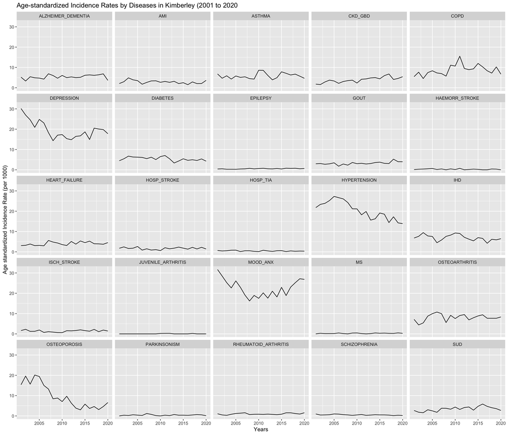

```r
# sample data

Incidence_CHSA_df %>%
  filter(HEALTH_BOUNDARIES == "1130 Kimberley") %>%
  ggplot(aes(x=YEAR, y=STD_RATE_PER_1000)) +
  geom_line() +
  facet_wrap(~DISEASE) +
  labs(x = "Years", y = "Age standardized Incidence Rate (per 1000)") +
  ggtitle("Age-standardized Incidence Rates by Diseases in Kimberley (2001 to 2020")
```

### Observations:

- “Breakpoints” can be seen. Not smooth
- Each “Piece” is considered a linear relation between Rates and Time (Year)

## Summery sattistics of rates:

```r
summary(HSC_CHSA_df$STD_RATE_PER_1000)
```

```
##    Min. 1st Qu.  Median    Mean 3rd Qu.    Max.    NA's
##    0.00    1.25    3.62   23.34   42.44  174.62    5060
```

```r
summary(Incidence_CHSA_df$STD_RATE_PER_1000)
```

```
##    Min. 1st Qu.  Median    Mean 3rd Qu.    Max.    NA's
##    0.00    0.65    2.81    5.36    6.94  201.50   11500
```

```r
summary(LifeP_CHSA_df$STD_RATE_PER_1000)
```

```
##    Min. 1st Qu.  Median    Mean 3rd Qu.    Max.    NA's
##    0.00    6.95   20.62   57.93   77.00  431.14   11500
```

### Observations: (Will elaborate later)

- None of the three rates, namely, HSC Prevalence, Age-Standardized Incidence Rate, and Age-Standardized Life Prevalence have any negative value

# Building the Model on sample data:

## Specifics :

- Model : Segmented regression / Joinpoint regression / Piecewise regression
- Response (y): Age-Standardized Incidence Rate
- Predictor : Year
- `segmented.lm` is used
- Filtering ALZHEIMER_DEMENTIA and 3213 Fairview CHSA

```r
sample_df <- Incidence_CHSA_df %>%
  filter(HEALTH_BOUNDARIES == "3213 Fairview" &
           DISEASE == "ALZHEIMER_DEMENTIA")

lm_model <- lm(log(STD_RATE_PER_1000)~YEAR, data = sample_df)
seg_obj<-segmented(lm_model,seg.Z=~YEAR)
```

## Model daignostics:

### Regression coefficients:

```r
print(summary(seg_obj))
```

```
##
##  ***Regression Model with Segmented Relationship(s)***
##
## Call:
## segmented.lm(obj = lm_model, seg.Z = ~YEAR)
##
## Estimated Break-Point(s):
##            Est. St.Err
## psi1.YEAR 2009  1.358
##
## Meaningful coefficients of the linear terms:
##               Estimate Std. Error t value Pr(>|t|)
## (Intercept) -129.21097   32.27064  -4.004 0.001023 **
## YEAR           0.06535    0.01610   4.060 0.000909 ***
## U1.YEAR       -0.08189    0.02001  -4.093       NA
## ---
## Signif. codes:  0 '***' 0.001 '**' 0.01 '*' 0.05 '.' 0.1 ' ' 1
##
## Residual standard error: 0.1247 on 16 degrees of freedom
## Multiple R-Squared: 0.6262,  Adjusted R-squared: 0.5561
##
## Boot restarting based on 6 samples. Last fit:
## Convergence attained in 2 iterations (rel. change 6.9538e-08)
```

#### Observations:

- Breakpoint is in Year 2009

### Average Annual Percent (AAPC) change:

To summarize piecewise linear relationships in segmented regression models.

```r
print(aapc(seg_obj, wrong.se = FALSE))
```

```
##        Est.      St.Err   CI(95%).l   CI(95%).u
## 0.017942849 0.005474024 0.007213960 0.028671738
```

#### Observations:

- Positive AAPC refers to an increasing trend

## Plotting:

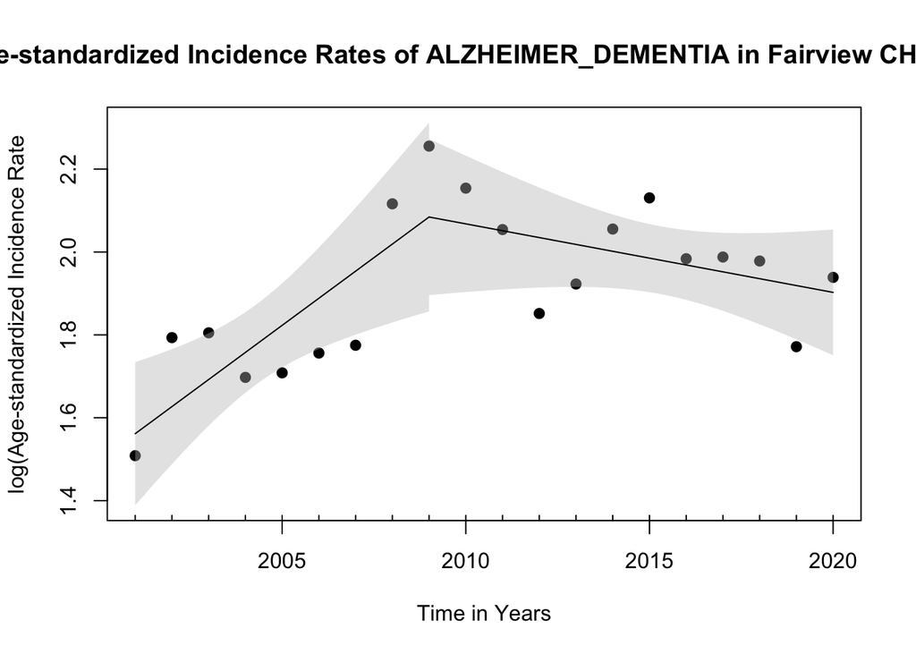

```r
plot(seg_obj,
     conf.level=.95,
     is=TRUE, isV=FALSE,
     col=1, shade = TRUE,
     res=TRUE,
     res.col=1,
     pch=19,
     main = "Predicted Age-standardized Incidence Rates of ALZHEIMER_DEMENTIA in Fairview CHSA (2001 to 2020)",
     xlab = "Time in Years",
     ylab = "log(Age-standardized Incidence Rate")
```

#### Observations:

- Epidemiological emphasis: Possible causes can be explored looking at the “Breakpoint” of Year 2009.

# Fitting the Model on data frame:

## Incidence rate:

### Model fitting:

```r
nested_incidence_df <- Incidence_CHSA_df %>%
  filter(anyTRUE==TRUE)%>%
  group_by(HEALTH_BOUNDARIES, DISEASE) %>%
  arrange(HEALTH_BOUNDARIES, DISEASE, YEAR) %>%
  nest() %>%
  mutate(fit = map(data, ~segmented(lm(log(STD_RATE_PER_1000)~ YEAR,
               na.action= na.exclude,
               data=.), seg.Z = ~YEAR)),
         results = map(fit, augment))%>%
  unnest(results)
```

### Display of results:

```r
view_incidence_df <- nested_incidence_df %>%
  dplyr::select(c(`DISEASE`,
                  `HEALTH_BOUNDARIES`,
                  `YEAR`,
                  `log(STD_RATE_PER_1000)`,
                  `psi1.YEAR`,
                  `.fitted`))
head(view_incidence_df)
```

| DISEASE | HEALTH_BOUNDARIES | YEAR | log(STD_RATE_PER_1000) | psi1.YEAR | .fitted |
| --- | --- | --- | --- | --- | --- |
| AMI | 1110 Fernie | 2001 | 1.1378330 | 0 | 1.094816 |
| AMI | 1110 Fernie | 2002 | 1.1184149 | 0 | 1.112710 |
| AMI | 1110 Fernie | 2003 | 1.1908876 | 0 | 1.130604 |
| AMI | 1110 Fernie | 2004 | 1.3532545 | 0 | 1.148499 |
| AMI | 1110 Fernie | 2005 | 0.6830968 | 0 | 1.166393 |
| AMI | 1110 Fernie | 2006 | 1.2325603 | 0 | 1.184287 |

### Saving data by diseases:

```r
incidence_df <- view_incidence_df %>%
  mutate(join_fitted = exp(.fitted)) %>%
  dplyr::select(c(DISEASE,
           HEALTH_BOUNDARIES,
           YEAR,
           join_fitted))

final_incidence_df <- Incidence_CHSA_df %>%
  full_join(incidence_df, by = c("DISEASE", "HEALTH_BOUNDARIES", "YEAR"))%>%
  rename(join_obs = STD_RATE_PER_1000)%>%
  dplyr::select(c(DISEASE,
           HEALTH_BOUNDARIES,
           YEAR,
           join_obs,
           join_fitted))

# Split dataframe by DISEASE
incidence_df_list <- split(final_incidence_df, list(final_incidence_df$DISEASE))

# Write out separate CSV for each DISEASE
for (DISEASE in names(incidence_df_list)) {
    write.csv(incidence_df_list[[DISEASE]], paste0("IncidenceRate/",DISEASE, ".csv"), row.names = FALSE)
}
```

## HSC prevalence:

### Model Fitting:

```r
nested_HSC_df <- HSC_CHSA_df %>%
  filter(anyTRUE==TRUE)%>%
  group_by(HEALTH_BOUNDARIES, DISEASE) %>%
  arrange(HEALTH_BOUNDARIES, DISEASE, YEAR) %>%
  nest() %>%
  mutate(fit = map(data, ~segmented(lm(log(STD_RATE_PER_1000)~ YEAR,
               na.action= na.exclude,
               data=.), seg.Z = ~YEAR)),
         results = map(fit, augment))%>%
  unnest(results)
```

### Display of results:

```r
view_HSC_df <- nested_HSC_df %>%
  dplyr::select(c(`DISEASE`,
                  `HEALTH_BOUNDARIES`,
                  `YEAR`,
                  `log(STD_RATE_PER_1000)`,
                  `psi1.YEAR`,
                  `.fitted`))
head(view_HSC_df)
```

| DISEASE | HEALTH_BOUNDARIES | YEAR | log(STD_RATE_PER_1000) | psi1.YEAR | .fitted |
| --- | --- | --- | --- | --- | --- |
| AMI_EPI | 1110 Fernie | 2001 | 1.1537316 | 0 | 1.098775 |
| AMI_EPI | 1110 Fernie | 2002 | 1.1019401 | 0 | 1.135931 |
| AMI_EPI | 1110 Fernie | 2003 | 1.1847900 | 0 | 1.173087 |
| AMI_EPI | 1110 Fernie | 2004 | 1.3887912 | 0 | 1.210243 |
| AMI_EPI | 1110 Fernie | 2005 | 0.8415672 | 0 | 1.247399 |
| AMI_EPI | 1110 Fernie | 2006 | 1.5085120 | 0 | 1.284556 |

### Saving data by diseases:

```r
HSC_df_list <- view_HSC_df %>%
  mutate(join_obs = exp(`log(STD_RATE_PER_1000)`)) %>%
  mutate(join_fitted = exp(.fitted)) %>%
  dplyr::select(c(DISEASE,
           HEALTH_BOUNDARIES,
           YEAR,
           join_obs,
           join_fitted))

HSC_df <- view_HSC_df %>%
  mutate(join_fitted = exp(.fitted)) %>%
  dplyr::select(c(DISEASE,
           HEALTH_BOUNDARIES,
           YEAR,
           join_fitted))

final_HSC_df <- HSC_CHSA_df %>%
  full_join(HSC_df, by = c("DISEASE", "HEALTH_BOUNDARIES", "YEAR"))%>%
  rename(join_obs = STD_RATE_PER_1000)%>%
  dplyr::select(c(DISEASE,
           HEALTH_BOUNDARIES,
           YEAR,
           join_obs,
           join_fitted))

# Split dataframe by DISEASE
HSC_df_list <- split(final_HSC_df, list(final_HSC_df$DISEASE))

# Write out separate CSV for each DISEASE
for (DISEASE in names(HSC_df_list)) {
    write.csv(HSC_df_list[[DISEASE]], paste0("HSCPrevalence/", DISEASE, ".csv"), row.names = FALSE)
}
```

## Life Prevalence rate:

### Model Fitting:

```r
nested_LifeP_df <- LifeP_CHSA_df %>%
  filter(anyTRUE==TRUE)%>%
  group_by(HEALTH_BOUNDARIES, DISEASE) %>%
  arrange(HEALTH_BOUNDARIES, DISEASE, YEAR) %>%
  nest() %>%
  mutate(fit = map(data, ~segmented(lm(log(STD_RATE_PER_1000)~ YEAR,
               na.action= na.exclude,
               data=.), seg.Z = ~YEAR)),
         results = map(fit, augment))%>%
  unnest(results)
```

### Display of results:

```r
view_LifeP_df <- nested_LifeP_df %>%
  dplyr::select(c(`DISEASE`,
                  `HEALTH_BOUNDARIES`,
                  `YEAR`,
                  `log(STD_RATE_PER_1000)`,
                  `psi1.YEAR`,
                  `.fitted`))
head(view_LifeP_df)
```

| DISEASE | HEALTH_BOUNDARIES | YEAR | log(STD_RATE_PER_1000) | psi1.YEAR | .fitted |
| --- | --- | --- | --- | --- | --- |
| ALZHEIMER_DEMENTIA | 1110 Fernie | 2001 | 2.816007 | 0 | 2.791057 |
| ALZHEIMER_DEMENTIA | 1110 Fernie | 2002 | 2.857619 | 0 | 2.835333 |
| ALZHEIMER_DEMENTIA | 1110 Fernie | 2003 | 2.834389 | 0 | 2.879608 |
| ALZHEIMER_DEMENTIA | 1110 Fernie | 2004 | 2.914522 | 0 | 2.923883 |
| ALZHEIMER_DEMENTIA | 1110 Fernie | 2005 | 2.999226 | 0 | 2.968158 |
| ALZHEIMER_DEMENTIA | 1110 Fernie | 2006 | 3.034472 | 0 | 3.012433 |

### Saving data by diseases:

```r
LifeP_df_list <- view_LifeP_df %>%
  mutate(join_obs = exp(`log(STD_RATE_PER_1000)`)) %>%
  mutate(join_fitted = exp(.fitted)) %>%
  dplyr::select(c(DISEASE,
           HEALTH_BOUNDARIES,
           YEAR,
           join_obs,
           join_fitted))

LifeP_df <- view_LifeP_df %>%
  mutate(join_fitted = exp(.fitted)) %>%
  dplyr::select(c(DISEASE,
           HEALTH_BOUNDARIES,
           YEAR,
           join_fitted))

final_LifeP_df <- LifeP_CHSA_df %>%
  full_join(LifeP_df, by = c("DISEASE", "HEALTH_BOUNDARIES", "YEAR"))%>%
  rename(join_obs = STD_RATE_PER_1000)%>%
  dplyr::select(c(DISEASE,
           HEALTH_BOUNDARIES,
           YEAR,
           join_obs,
           join_fitted))

# Split dataframe by DISEASE
LifeP_df_list <- split(final_LifeP_df, list(final_LifeP_df$DISEASE))

# Write out separate CSV for each DISEASE
for (DISEASE in names(LifeP_df_list)) {
    write.csv(LifeP_df_list[[DISEASE]], paste0("LifePrevalence/",DISEASE, ".csv"),row.names=FALSE)
}
```

# References

Ilic, Irena, Ivana Zivanovic Macuzic, Sanja Kocic, and Milena Ilic. 2022. “Worldwide Suicide Mortality Trends by Firearm (1990–2019): A Joinpoint Regression Analysis.” *PLoS One* 17 (5): e0267817.

Lui, Rashid N, Kelvin KF Tsoi, Jason MW Ho, CM Lo, Felix CH Chan, Moe H Kyaw, and Joseph JY Sung. 2019. “Global Increasing Incidence of Young-Onset Colorectal Cancer Across 5 Continents: A Joinpoint Regression Analysis of 1,922,167 Cases.” *Cancer Epidemiology and Prevention Biomarkers* 28 (8): 1275–82.

Muggeo, Vito MR. 2003. “Estimating Regression Models with Unknown Break-Points.” *Statistics in Medicine* 22 (19): 3055–71.

Muggeo, Vito MR et al. 2008. “Segmented: An r Package to Fit Regression Models with Broken-Line Relationships.” *R News* 8 (1): 20–25.

Núñez-González, Solange, Estefania Bedoya, Daniel Simancas-Racines, and Christopher Gault. 2020. “Spatial Clusters and Temporal Trends of Malignant Melanoma Mortality in Ecuador.” *SAGE Open Medicine* 8: 2050312120918285.